# Prosper Loan Data Analysis

## by Awele Esealuka

## Investigation Overview

In this investigation, I wanted to look at features that might affect the borrower rate and loan amount that borrowers get in the Prosper Loan dataset. For the presentation, I focused on just the influence of the Prosper rating, Prosper score, Credit score, and monthly income on loan amount and borrower rate, as well as home ownership.

## Dataset Overview

The dataset consists of 76,768 rows and 19 colums containing data of Prosper loans from the year 2009 to 2014. I removed some rows and columns from the original dataset, also added new columns in order to get the one I worked with in this presentation.

## Distribution of Borrower Rate

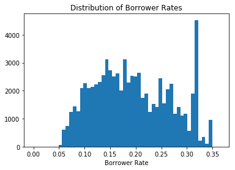

## Distribution of Loan Amount

> The Loan original amount has a multimodal distribution, with the highest peaks around \$4K, \\$10K, and \$15K. Most of the loans taken have values less that \\$10,000, very few loans have values greater than \$26,000

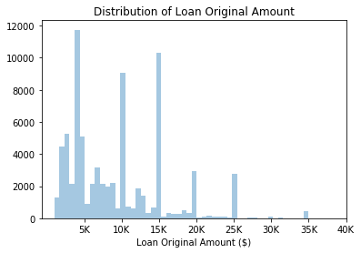

## Relationship between Borrower Rate, Credit Score and Monthly Loan Payment

Borrowers with higher credit scores have higher proportion of low borrower rates, those with very good credit scores have few loans with borrower rates greater than 0.2. Also, borrowers with higher monthly payments have lower credit rates generally.

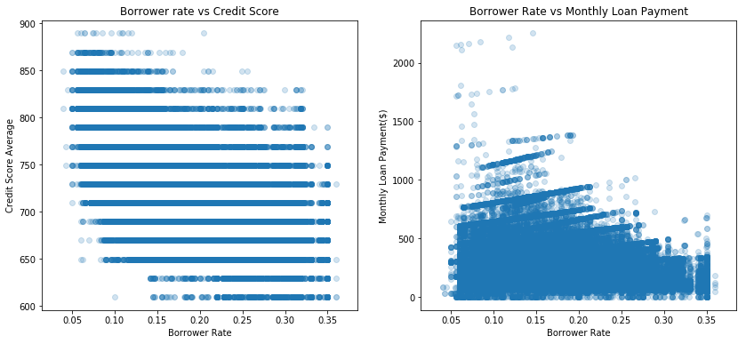

## Relationship between Borrower Rate, Prosper Score and Prosper Rating

Borrowers with better Prosper ratings (A, AA) generally had lower interest rates, which might mean Prosper rewards borrowers with good Prosper ratings with lower borrower rates. Borrowers with higher risk scores(Prosper Score, best is 11, worst is 1) had lower interest rates, and those with lower risk scores had higher borrower rates.

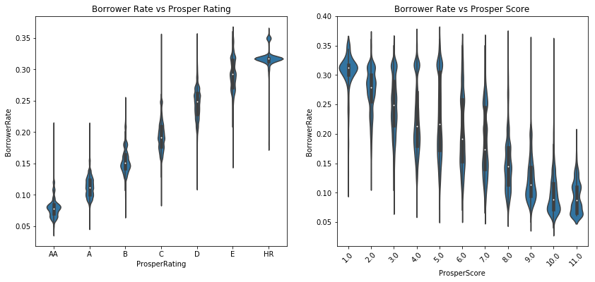

## Relationship between Loan Amount, Credit Score and Monthly Loan Payment

Borrowers with good credit scores had higher value loans than those with poor/average credit scores. Also, as expected, there is a positive correlation between loan amount and monthly loan payment.

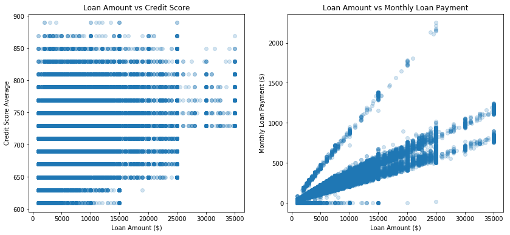

## Relationship between Loan Amount, Prosper Score and Prosper Rating

Most borrowers with poor ratings(E, HR) have low value loans, less than $5K. The value of loans in each category reduces as the rating reduces. Also, the lower risk scores are more populated with lower value loans, the chances of getting a high value loan decreases as the ProsperScore decreases.

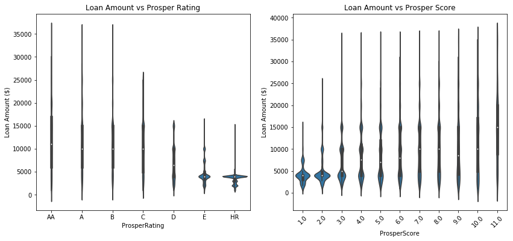

## Relationship between Loan Amount, Borrower Rate and Income Range

As expected, lower income earners borrow smaller amounts, and high income earners have a higher proportion of low borrower rates

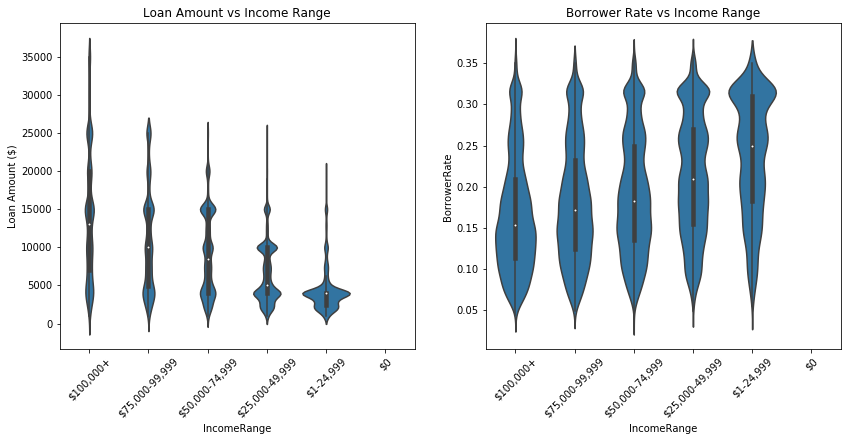

## Loan Amount by Income Range and Home Ownership

There's a slight increase in the proportion of high value loans given to home owners than non home owners. A higher income and being a home owner might increase the chances of getting a high value loan.

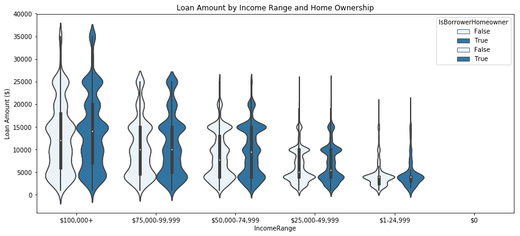

## Relationship between Prosper Score and Income Range

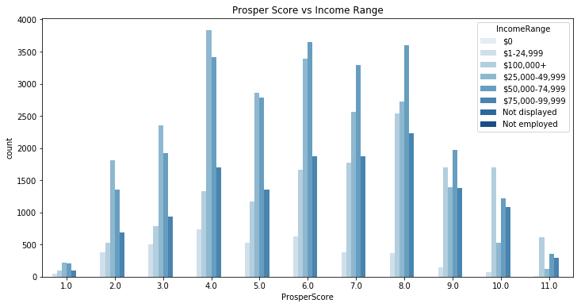